# Credit Card Users Churn Prediction

### Model Building with Oversampled data

```python
# Synthetic Minority Over Sampling Technique
sm = SMOTE(sampling_strategy=1, k_neighbors=5, random_state=1)
X_train_over, y_train_over = sm.fit_resample(X_train, y_train)
```

```python
print("Before OverSampling, count of label '1': {}".format(sum(y_train == 1)))
print("Before OverSampling, count of label '0': {} \n".format(sum(y_train == 0)))

print("After OverSampling, count of label '1': {}".format(sum(y_train_over == 1)))
print("After OverSampling, count of label '0': {} \n".format(sum(y_train_over == 0)))

print("After OverSampling, the shape of train_X: {}".format(X_train_over.shape))
print("After OverSampling, the shape of train_y: {} \n".format(y_train_over.shape))
```

```
Before OverSampling, count of label '1': 5099
Before OverSampling, count of label '0': 976

After OverSampling, count of label '1': 5099
After OverSampling, count of label '0': 5099

After OverSampling, the shape of train_X: (10198, 19)
After OverSampling, the shape of train_y: (10198,)
```

```python
print("\n" "Training Performance with oversampled data:" "\n")
for name, model in models:
    model.fit(X_train_over, y_train_over)
    scores = recall_score(y_train_over, model.predict(X_train_over))
    print("{}: {}".format(name, scores))

print("\n" "Validation Performance:" "\n")

for name, model in models:
    model.fit(X_train_over, y_train_over)
    scores_val = recall_score(y_val, model.predict(X_val))
    print("{}: {}".format(name, scores_val))
```

```
Training Performance with oversampled data:

Bagging: 0.9954893116297313
Random forest: 1.0
DecisionTree: 1.0
AdaBoost: 0.9497940772700529
Gradient: 0.9682290645224554

Validation Performance:

Bagging: 0.9535294117647058
Random forest: 0.97
DecisionTree: 0.9841176470588235
AdaBoost: 0.9511764705882353
Gradient: 0.9676470588235294
```

```
Testing performance: Bagging
    Accuracy  Recall  Precision    F1
0     0.946   0.961      0.974 0.967
++++++++++++++++++++++++++++++- model_nm- Bagging-++++++++++++++++++++++++++++++
Testing performance: Random forest
    Accuracy  Recall  Precision    F1
0     0.957   0.975      0.974 0.974
++++++++++++++++++++++++++++++- model_nm- Random forest-++++++++++++++++++++++++++++++
Testing performance: DecisionTree
    Accuracy  Recall  Precision    F1
0     0.969   0.984      0.980 0.982
++++++++++++++++++++++++++++++- model_nm- DecisionTree-++++++++++++++++++++++++++++++
Testing performance: AdaBoost
    Accuracy  Recall  Precision    F1
0     0.946   0.953      0.982 0.967
++++++++++++++++++++++++++++++- model_nm- AdaBoost-++++++++++++++++++++++++++++++
Testing performance: Gradient
    Accuracy  Recall  Precision    F1
0     0.959   0.971      0.980 0.975
++++++++++++++++++++++++++++++- model_nm- Gradient-++++++++++++++++++++++++++++++
```

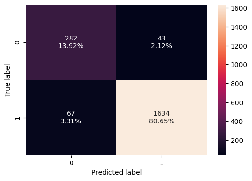

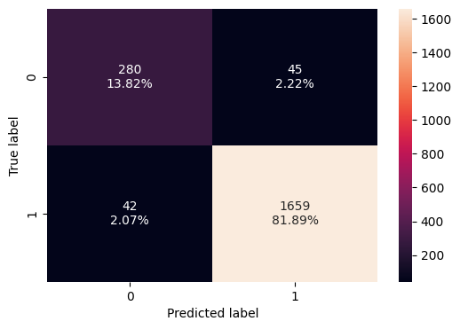

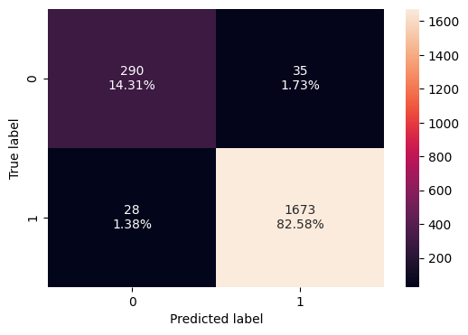

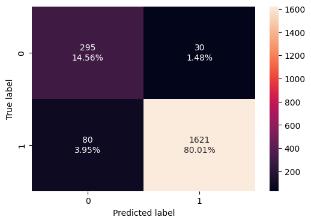

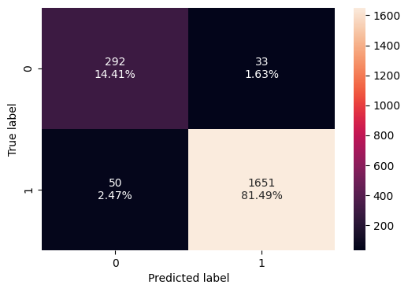

```python
for name, model in models:
    model_test_perf = model_performance_classification_sklearn(model,X_test,y_test)
    print(f"Testing performance: {name}\n",model_test_perf)
    print(f"{'+'*30}- model_nm- {name}-{'+'*30}")
    #Creating confusion matrix
    confusion_matrix_sklearn(model,X_test,y_test)
```

A great improvement is not found during oversampling in all the models, a few model are showing different validation results after oversampling- like Bagging, ADABoost and Gradient

### Model Building with Undersampled data

```python
# Random undersampler for under sampling the data
rus = RandomUnderSampler(random_state=1, sampling_strategy=1)
X_train_un, y_train_un = rus.fit_resample(X_train, y_train)
```

```python
print("Before UnderSampling, count of label '1': {}".format(sum(y_train == 1)))
print("Before UnderSampling, count of label '0': {} \n".format(sum(y_train == 0)))

print("After UnderSampling, count of label '1': {}".format(sum(y_train_un == 1)))
print("After UnderSampling, count of label '0': {} \n".format(sum(y_train_un == 0)))

print("After UnderSampling, the shape of train_X: {}".format(X_train_un.shape))
print("After UnderSampling, the shape of train_y: {} \n".format(y_train_un.shape))
```

```
Before UnderSampling, count of label '1': 5099
Before UnderSampling, count of label '0': 976

After UnderSampling, count of label '1': 976
After UnderSampling, count of label '0': 976

After UnderSampling, the shape of train_X: (1952, 19)
After UnderSampling, the shape of train_y: (1952,)
```

```python
print("\n" "Training Performance with oversampled data:" "\n")
for name, model in models:
    model.fit(X_train_un, y_train_un)
    scores = recall_score(y_train_un, model.predict(X_train_un))
    print("{}: {}".format(name, scores))

print("\n" "Validation Performance:" "\n")

for name, model in models:
    model.fit(X_train_un, y_train_un)
    scores_val = recall_score(y_val, model.predict(X_val))
    print("{}: {}".format(name, scores_val))
```

```
Training Performance with oversampled data:

Bagging: 0.9938524590163934
Random forest: 1.0
DecisionTree: 1.0
AdaBoost: 0.9426229508196722
Gradient: 0.9692622950819673

Validation Performance:

Bagging: 0.9235294117647059
Random forest: 0.9458823529411765
DecisionTree: 0.9588235294117647
AdaBoost: 0.9317647058823529
Gradient: 0.9529411764705882
```

```
Testing performance: Bagging
    Accuracy  Recall  Precision    F1
0     0.913   0.914      0.982 0.946
++++++++++++++++++++++++++++++- model_nm- Bagging-++++++++++++++++++++++++++++++
Testing performance: Random forest
    Accuracy  Recall  Precision    F1
0     0.934   0.937      0.984 0.960
++++++++++++++++++++++++++++++- model_nm- Random forest-++++++++++++++++++++++++++++++
Testing performance: DecisionTree
    Accuracy  Recall  Precision    F1
0     0.953   0.955      0.988 0.972
++++++++++++++++++++++++++++++- model_nm- DecisionTree-++++++++++++++++++++++++++++++
Testing performance: AdaBoost
    Accuracy  Recall  Precision    F1
0     0.934   0.931      0.990 0.960
++++++++++++++++++++++++++++++- model_nm- AdaBoost-++++++++++++++++++++++++++++++
Testing performance: Gradient
    Accuracy  Recall  Precision    F1
0     0.942   0.944      0.986 0.965
++++++++++++++++++++++++++++++- model_nm- Gradient-++++++++++++++++++++++++++++++
```

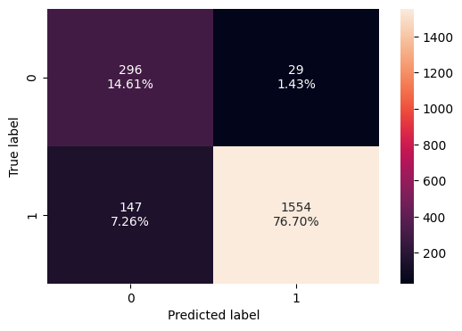

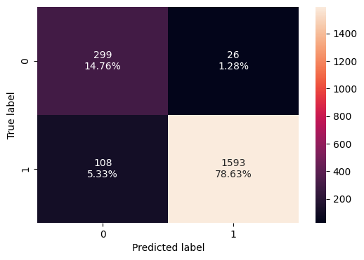

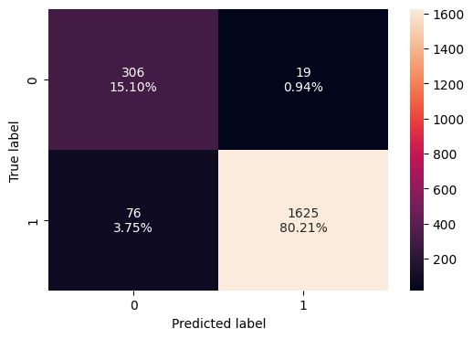

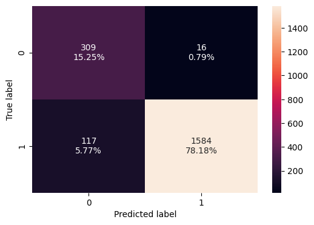

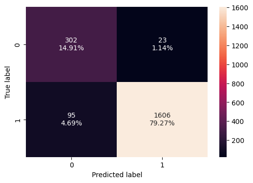

```python
for name, model in models:
    model_test_perf = model_performance_classification_sklearn(model,X_test,y_test)
    print(f"Testing performance: {name}\n",model_test_perf)
    print(f"{'+'*30}- model_nm- {name}-{'+'*30}")
    #Creating confusion matrix
    confusion_matrix_sklearn(model,X_test,y_test)
```

## HyperparameterTuning

#### Sample Parameter Grids

**Note**

1. Sample parameter grids have been provided to do necessary hyperparameter tuning. These sample grids are expected to provide a balance between model performance improvement and execution time. One can extend/reduce the parameter grid based on execution time and system configuration.
   - Please note that if the parameter grid is extended to improve the model performance further, the execution time will increase
- For Gradient Boosting:

```
param_grid = {
    "init": [AdaBoostClassifier(random_state=1),DecisionTreeClassifier(random_state=1)],
    "n_estimators": np.arange(50,110,25),
    "learning_rate": [0.01,0.1,0.05],
    "subsample":[0.7,0.9],
    "max_features":[0.5,0.7,1],
}
```

- For Adaboost:

```
param_grid = {
    "n_estimators": np.arange(50,110,25),
    "learning_rate": [0.01,0.1,0.05],
    "base_estimator": [
        DecisionTreeClassifier(max_depth=2, random_state=1),
        DecisionTreeClassifier(max_depth=3, random_state=1),
    ],
}
```

- For Bagging Classifier:

```
param_grid = {
    'max_samples': [0.8,0.9,1],
    'max_features': [0.7,0.8,0.9],
    'n_estimators' : [30,50,70],
}
```

- For Random Forest:

```
param_grid = {
    "n_estimators": [50,110,25],
    "min_samples_leaf": np.arange(1, 4),
    "max_features": [np.arange(0.3, 0.6, 0.1),'sqrt'],
    "max_samples": np.arange(0.4, 0.7, 0.1)
}
```

- For Decision Trees:

```
param_grid = {
    'max_depth': np.arange(2,6),
    'min_samples_leaf': [1, 4, 7],
    'max_leaf_nodes' : [10, 15],
    'min_impurity_decrease': [0.0001,0.001]
}
```

- For XGBoost (optional):

```
param_grid={'n_estimators':np.arange(50,110,25),
            'scale_pos_weight':[1,2,5],
            'learning_rate':[0.01,0.1,0.05],
            'gamma':[1,3],
            'subsample':[0.7,0.9]
}
```

#### Sample tuning method for different models using normal, undersampling and over sampling data

```python
# DT HT params
Model = DecisionTreeClassifier(random_state=1)

# Parameter grid to pass in RandomSearchCV
param_grid = {'max_depth': np.arange(2,6),
              'min_samples_leaf': [1, 4, 7],
              'max_leaf_nodes' : [10,15],
              'min_impurity_decrease': [0.0001,0.001] }

#Calling RandomizedSearchCV
randomized_cv = RandomizedSearchCV(estimator=Model, param_distributions=param_grid, n_iter=10, n_jobs = -1, scoring=scorer, cv=5, random_state=1)

#Fitting parameters in RandomizedSearchCV
randomized_cv.fit(X_train,y_train)
dt_normal_ht_params = randomized_cv.best_params_

randomized_cv.fit(X_train_over,y_train_over)
dt_os_ht_params = randomized_cv.best_params_

randomized_cv.fit(X_train_un,y_train_un)
dt_un_ht_params = randomized_cv.best_params_
print(f"dt_un_ht_params - {dt_un_ht_params}")
```

```
dt_un_ht_params - {'min_samples_leaf': 1, 'min_impurity_decrease': 0.0001, 'max_leaf_nodes': 10, 'max_depth': 5}
```

```python
print(f"dt_normal_ht_params - {dt_normal_ht_params}")
print(f"dt_os_ht_params - {dt_os_ht_params}")
print(f"dt_un_ht_params - {dt_un_ht_params}")
```

```
dt_normal_ht_params - {'min_samples_leaf': 7, 'min_impurity_decrease': 0.0001, 'max_leaf_nodes': 15, 'max_depth': 5}
dt_os_ht_params - {'min_samples_leaf': 7, 'min_impurity_decrease': 0.0001, 'max_leaf_nodes': 15, 'max_depth': 5}
dt_un_ht_params - {'min_samples_leaf': 1, 'min_impurity_decrease': 0.0001, 'max_leaf_nodes': 10, 'max_depth': 5}
```

```python
# Bagging HT params
bagging_estimator_tuned = BaggingClassifier(random_state=1)

# Grid of parameters to choose from
# parameters = {'max_samples': [0.7,0.8,0.9,1],
#               'max_features': [0.7,0.8,0.9,1],
#               'n_estimators' : [10,20,30,40,50],
#              }
# since the resource on colab are not sufficient enough and chagning the params
parameters = {'max_samples': [0.7,0.8],
              'max_features': [0.7,0.8],
              'n_estimators' : [10,20],
             }

# Type of scoring used to compare parameter combinations
scorer = metrics.make_scorer(metrics.f1_score)

# Run the grid search
grid_obj = GridSearchCV(bagging_estimator_tuned, parameters, scoring=scorer,cv=5)

grid_obj = grid_obj.fit(X_train, y_train)
bagging_normal_ht_params = grid_obj.best_params_

grid_obj = grid_obj.fit(X_train_over, y_train_over)
bagging_over_ht_params = grid_obj.best_params_

grid_obj = grid_obj.fit(X_train_un, y_train_un)
bagging_un_ht_params = grid_obj.best_params_
```

```python
print(f"bagging_normal_ht_params - {bagging_normal_ht_params}")
print(f"bagging_over_ht_params - {bagging_over_ht_params}")
print(f"bagging_un_ht_params - {bagging_un_ht_params}")
```

[output not shown]

```python
ada_tuned = AdaBoostClassifier(random_state=1)

# Grid of parameters to choose from
parameters = {
    #Let's try different max_depth for base_estimator
    "base_estimator":[DecisionTreeClassifier(max_depth=1),DecisionTreeClassifier(max_depth=2)],
    "n_estimators": np.arange(10,30,10),
    "learning_rate":np.arange(0.1,1,0.5)
}

# Type of scoring used to compare parameter  combinations
scorer = metrics.make_scorer(metrics.f1_score)

# Run the grid search
grid_obj = GridSearchCV(ada_tuned, parameters, scoring=scorer,cv=5)

grid_obj = grid_obj.fit(X_train, y_train)
ada_normal_ht_params = grid_obj.best_params_

grid_obj = grid_obj.fit(X_train_over, y_train_over)
ada_over_ht_params = grid_obj.best_params_

grid_obj = grid_obj.fit(X_train_un, y_train_un)
ada_un_ht_params = grid_obj.best_params_
```

```python
print(f"ada_normal_ht_params - {ada_normal_ht_params}")
print(f"ada_over_ht_params - {ada_over_ht_params}")
print(f"ada_un_ht_params - {ada_un_ht_params}")
```

```
ada_normal_ht_params - {'base_estimator': DecisionTreeClassifier(max_depth=2), 'learning_rate': 0.6, 'n_estimators': 20}
ada_over_ht_params - {'base_estimator': DecisionTreeClassifier(max_depth=2), 'learning_rate': 0.6, 'n_estimators': 20}
ada_un_ht_params - {'base_estimator': DecisionTreeClassifier(max_depth=2), 'learning_rate': 0.6, 'n_estimators': 20}
```

```python
grad_tuned = GradientBoostingClassifier(init=AdaBoostClassifier(random_state=1),random_state=1)

# Grid of parameters to choose from
# going with minmum configs to stabilize the colab resources
parameters = {
    "n_estimators": [20,30],
    "subsample":[0.8,0.9],
    "max_features":[0.7,0.8]
}

# Type of scoring used to compare parameter combinations
scorer = metrics.make_scorer(metrics.f1_score)

# Run the grid search
grid_obj = GridSearchCV(grad_tuned, parameters, scoring=scorer,cv=5)

grid_obj = grid_obj.fit(X_train, y_train)
grad_normal_ht_params = grid_obj.best_params_

grid_obj = grid_obj.fit(X_train_over, y_train_over)
grad_over_ht_params = grid_obj.best_params_

grid_obj = grid_obj.fit(X_train_un, y_train_un)
grad_un_ht_params = grid_obj.best_params_
```

```python
print(f"grad_normal_ht_params - {grad_normal_ht_params}")
print(f"grad_over_ht_params - {grad_over_ht_params}")
print(f"grad_un_ht_params - {grad_un_ht_params}")
```

```
grad_normal_ht_params - {'max_features': 0.8, 'n_estimators': 30, 'subsample': 0.9}
grad_over_ht_params - {'max_features': 0.7, 'n_estimators': 30, 'subsample': 0.8}
grad_un_ht_params - {'max_features': 0.8, 'n_estimators': 30, 'subsample': 0.8}
```

```python
rf_tuned = RandomForestClassifier(class_weight={0:0.18,1:0.82},random_state=1,oob_score=True,bootstrap=True)

parameters = {
                'max_depth': list(np.arange(5,20,5)) + [None],
                'max_features': ['sqrt','log2',None],
                'min_samples_leaf': np.arange(1,10,5),
                'min_samples_split': np.arange(2, 10, 5),
                'n_estimators': np.arange(10,20,10)}


# Type of scoring used to compare parameter combinations
scorer = metrics.make_scorer(metrics.f1_score)

# Run the grid search
grid_obj = GridSearchCV(rf_tuned, parameters, scoring=scorer, cv=5,n_jobs=-1)

grid_obj = grid_obj.fit(X_train, y_train)
rf_normal_ht_params = grid_obj.best_params_

grid_obj = grid_obj.fit(X_train_over, y_train_over)
rf_over_ht_params = grid_obj.best_params_

grid_obj = grid_obj.fit(X_train_un, y_train_un)
rf_un_ht_params = grid_obj.best_params_
```

```python
print(f"rf_normal_ht_params - {rf_normal_ht_params}")
print(f"rf_over_ht_params - {rf_over_ht_params}")
print(f"rf_un_ht_params - {rf_un_ht_params}")
```

```
rf_normal_ht_params - {'max_depth': None, 'max_features': None, 'min_samples_leaf': 1, 'min_samples_split': 2, 'n_estimators': 10}
rf_over_ht_params - {'max_depth': None, 'max_features': 'sqrt', 'min_samples_leaf': 1, 'min_samples_split': 7, 'n_estimators': 10}
rf_un_ht_params - {'max_depth': 10, 'max_features': None, 'min_samples_leaf': 1, 'min_samples_split': 2, 'n_estimators': 10}
```